# MSB 1015 Scientific Programming - Assignment 2

Ammar Ammar

October 12, 2019

## Dependencies

First, you have to check if the required packages are already installed. If not, install them:

```r
requiredPackages <- c("WikidataQueryServiceR", # run SPARQL query against Wikidata
                      "rJava",  # required for rcdk
                      "rcdk",   # cheminformatics library
                      "randomForest", # Random forest machine learning library
                      "caret",  # Classification And REgression Training
                      "dplyr",  # data manipulation library
                      "stringr", # string manipulation library
                      "pls",   # Partial Least Squares regression library
                      "measurements",  # library to convert to many units
                      "DT") # generate interactive data tables

for (pkg in requiredPackages) {
    if(! pkg %in% row.names(installed.packages())) install.packages(pkg)
}
```

Load the required packages:

```r
library(WikidataQueryServiceR)
library(rJava)
library(rcdk)
library(randomForest)
library(caret)
library(dplyr)
library(stringr)
library(pls)
library(measurements)
library(DT)
```

## Load Data

Prepare a SPARQL query to get alkanes with their smiles and boiling points from Wikidata

```r
sparql_query <- 'SELECT ?comp ?compLabel ?smile ?bp ?bpUnit ?bpUnitLabel WHERE {
  ?comp wdt:P31/wdt:P279* wd:Q41581 ;
        wdt:P233 ?smile ;
        p:P2102 [
          ps:P2102 ?bp ;
          psv:P2102/wikibase:quantityUnit  ?bpUnit
        ] .
  SERVICE wikibase:label { bd:serviceParam wikibase:language     "[AUTO_LANGUAGE],en". }
}'

results <- query_wikidata(sparql_query)
```

```
## 142 rows were returned by WDQS
```

```r
summary(results)
```

```
##      comp            compLabel            smile                 bp
##  Length:142         Length:142         Length:142         Min.   :-44.0
##  Class :character   Class :character   Class :character   1st Qu.:367.3
##  Mode  :character   Mode  :character   Mode  :character   Median :616.2
##                                                           Mean   :608.5
##                                                           3rd Qu.:908.9
##                                                           Max.   :994.1
##     bpUnit          bpUnitLabel
##  Length:142         Length:142
##  Class :character   Class :character
##  Mode  :character   Mode  :character
##
##
##
```

## Preprocess the data

Next, process the boiling point by looking at the unit label and convert from Fahrenheit and Celesius to Kelvin. Then, select only the alkan label, SMILE and boiling point into a new data frame:

```r
# if the unit in Fagrenheit or Celesius, use conv_unit function from the "measurements" library to convert the temprature to Kelvin
alkanesData <- results %>%
               mutate(bp = case_when(bpUnitLabel == "degree Fahrenheit" ~ conv_unit(bp ,"F","K"),
                                     bpUnitLabel == "degree Celsius" ~ conv_unit(bp ,"C","K"),
                                     TRUE ~ bp)) %>%
               select(compLabel, smile, bp)

# output the final alkanes data frame as interactive HTML table with sort, search and pagination functions
datatable(alkanesData[,c(1,3)], rownames = FALSE, filter="top", options = list(pageLength = 10, scrollX=T))
```

| compLabel | bp |
| --- | --- |
| Henheptacontane | 928.15 |
| Henpentacontane | 857.15 |
| Henoctacontane | 948.55 |
| Hennonacontane | 973.15 |
| Henhexacontane | 897.05 |
| Pentaheptacontane | 939.15 |
| 2,2-dimethylhexane | 386.5 |
| 2,3,4-trimethylpentane | 386.5 |
| Tetratriacontane | 756.15 |
| 3,3-dimethylhexane | 386.05 |

[output cut: 132 more lines]

## Calcualte the features (The Descriptors)

Parse the SMILE strings of the compounds and calculate all the descriptors for each one of them. Then, bind the boiling points column to the descriptors data frame:

```r
# parse the SMILE strings into IAtomCOntainer object for each Alkane compound
mols <- parse.smiles(alkanesData$smile)

# get a list of all descriptors available in CDK
descriptorsNames <- get.desc.names(type = "all")

# calculate the desctiptors for all the alkanes
descriptors <- eval.desc(mols, descriptorsNames)

# combine the descriptors values and the boiling points in one data frame
featuresDataframe <- cbind(descriptors, alkanesData$bp)

# change the name of the boiling point column into a more readable name
colnames(featuresDataframe)[ncol(featuresDataframe)] <- "bp"
```

## Clean the data

Remove the descriptors and molecules which have NA value(s):

```r
featuresDataframe <- featuresDataframe[,colSums(is.na(featuresDataframe)) < nrow(featuresDataframe)]

featuresDataframe <- featuresDataframe[rowSums(is.na(featuresDataframe)) == 0,]
```

## First Model: Prtial Least Squares

### Split the data

Randomly sample 20% of the total number of alkanes then create two datasets (train set and test set):

```r
# set a set to generate the same random numbers (for reproducibility)
set.seed(123)

# select ~20% test set
test_selection <- sample(nrow(featuresDataframe), 0.2 * nrow(featuresDataframe))

# create train and test datasets from the features dataframe
traint_set <- featuresDataframe[-test_selection,]
test_set <- featuresDataframe[test_selection,]
```

### Build the model

Here, we fit a partial least square model on the training set. This fits a model with 10 components, and includes leave-one-out (LOO) cross-validated predictions:

```r
pls_model <- plsr(bp ~ ., ncomp = 10, data = traint_set, validation = "LOO")

summary(pls_model)
```

```
## Data:    X dimension: 112 220
##  Y dimension: 112 1
## Fit method: kernelpls
## Number of components considered: 10
##
## VALIDATION: RMSEP
## Cross-validated using 112 leave-one-out segments.
##        (Intercept)  1 comps  2 comps  3 comps  4 comps  5 comps  6 comps
## CV           255.5    154.8    71.28    34.46    32.16    28.88    26.94
## adjCV        255.5    154.8    71.27    34.45    32.15    28.86    26.91
##        7 comps  8 comps  9 comps  10 comps
## CV       25.72    25.75    27.16     26.47
## adjCV    25.71    25.74    27.13     26.44
##
## TRAINING: % variance explained
##     1 comps  2 comps  3 comps  4 comps  5 comps  6 comps  7 comps  8 comps
## X     99.48   100.00   100.00   100.00   100.00   100.00   100.00   100.00
## bp    63.84    92.47    98.29    98.56    98.95    99.09    99.11    99.12
##     9 comps  10 comps
## X    100.00    100.00
## bp    99.15     99.16
```

The validation results in the following plot are Root Mean Squared Error of Prediction (RMSEP). There are two cross-validation estimates: CV is the ordinary CV estimate, and adjCV is a bias-corrected CV estimate. (For a LOO CV, there is virtually no difference). It is often simpler to judge the RMSEPs by plotting them:

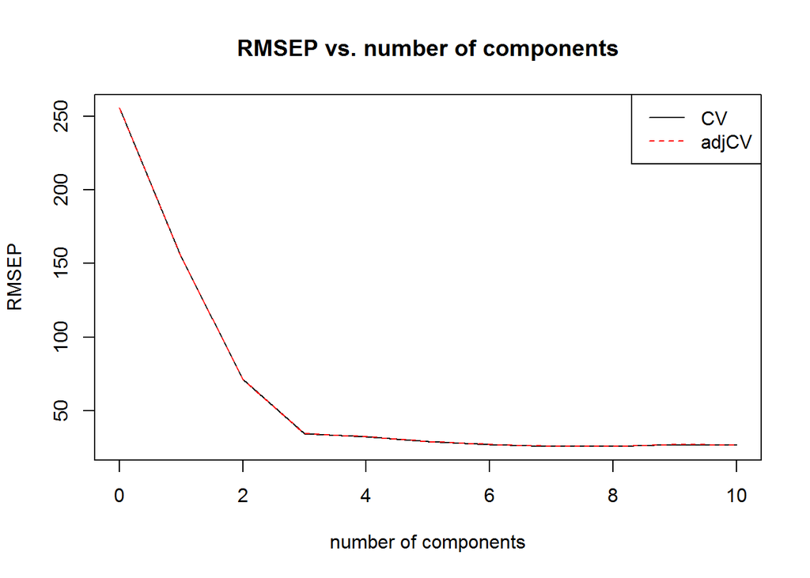

```r
#plot estimated RMSEPs as functions of the number of component.
#The legendpos argument adds a legend at the indicated position
plot(RMSEP(pls_model), legendpos = "topright", main="RMSEP vs. number of components")
```

```r
RMSEP(pls_model)
```

```
##        (Intercept)  1 comps  2 comps  3 comps  4 comps  5 comps  6 comps
## CV           255.5    154.8    71.28    34.46    32.16    28.88    26.94
## adjCV        255.5    154.8    71.27    34.45    32.15    28.86    26.91
##        7 comps  8 comps  9 comps  10 comps
## CV       25.72    25.75    27.16     26.47
## adjCV    25.71    25.74    27.13     26.44
```

**Three components seem to be enough**. Once the number of components has been chosen, one can inspect different aspects of the fit by plotting predictions, scores, correlation and coeffecients .. etc.

Left plot visualizes the regression coefficients for the first three components and shows the impact of the predictors on the boiling point. The X axis is the predictor index and the Y axis is the regression coeffecient.

Right plot shows the cross-validated predictions with three components versus measured values. We have chosen to draw a target line using the paramter line=TRUE.

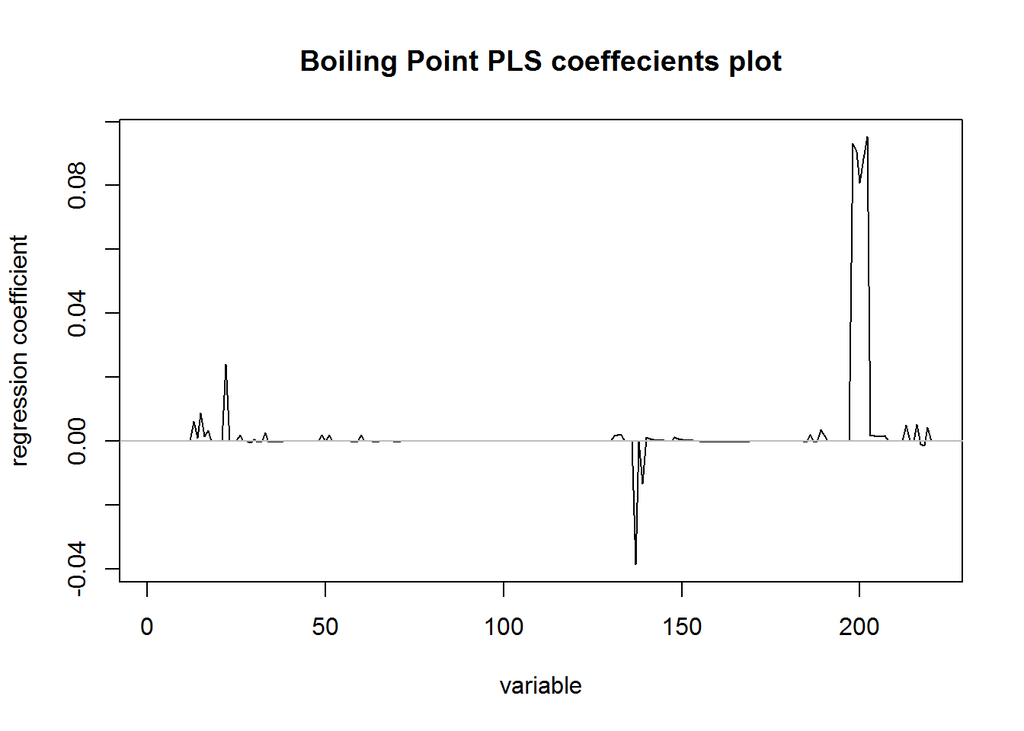

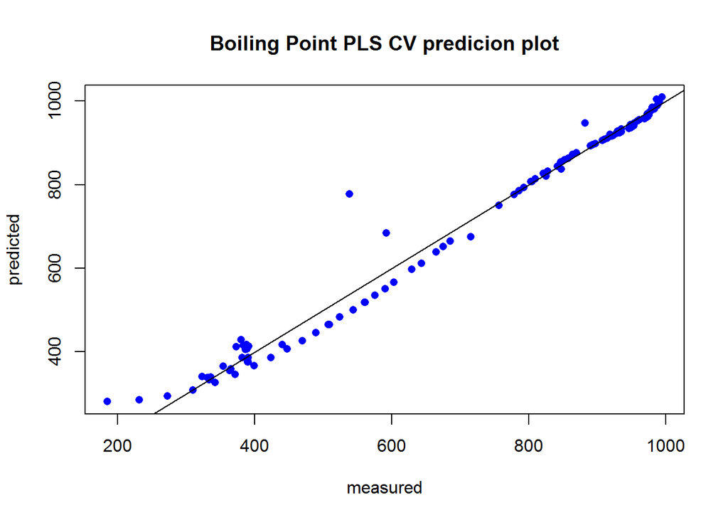

```r
plot(pls_model, plottype = "coeff", ncomp = 3, main="Boiling Point PLS coeffecients plot")

plot(pls_model, plottype = "prediction", ncomp = 3, main="Boiling Point PLS CV predicion plot", line=TRUE, pch=16,col="blue")
```

### Apply prediction

```r
# use the fitted model to predict the values of the test dataset using 3 components
predicted_test <- predict(pls_model, ncomp = 3, newdata = test_set)
```

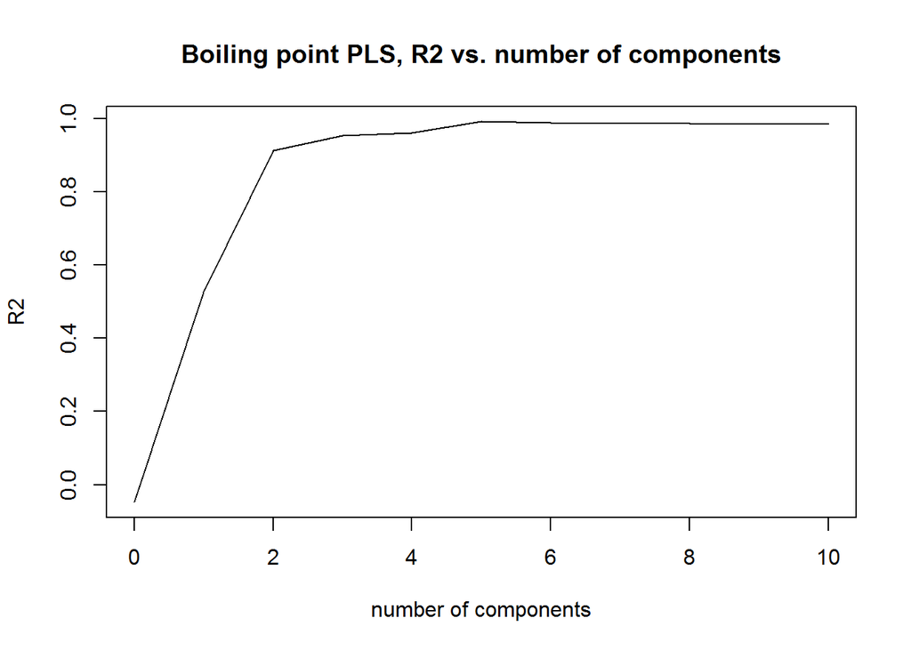

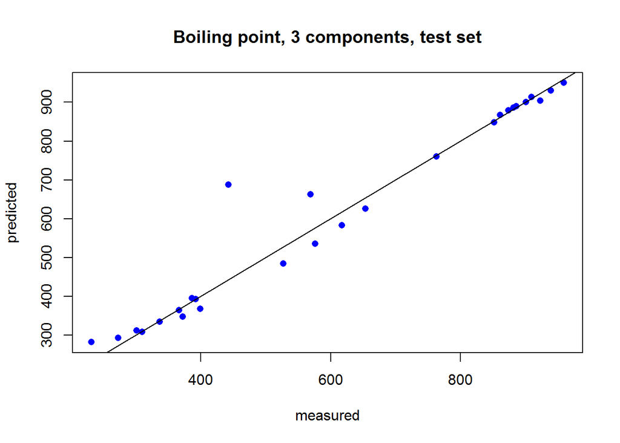

```r
# plot the R2 values as a measure of prediction performance
plot(R2(pls_model, newdata = test_set), main="Boiling point PLS, R2 vs. number of components")

# plot the predictet value vs. the measured values of the test set
predplot(pls_model, ncomp = 3, newdata = test_set, line = TRUE, pch=16,col="blue", main="Boiling point, 3 components, test set")
```

Also, we report the RMSEP plot for the test set

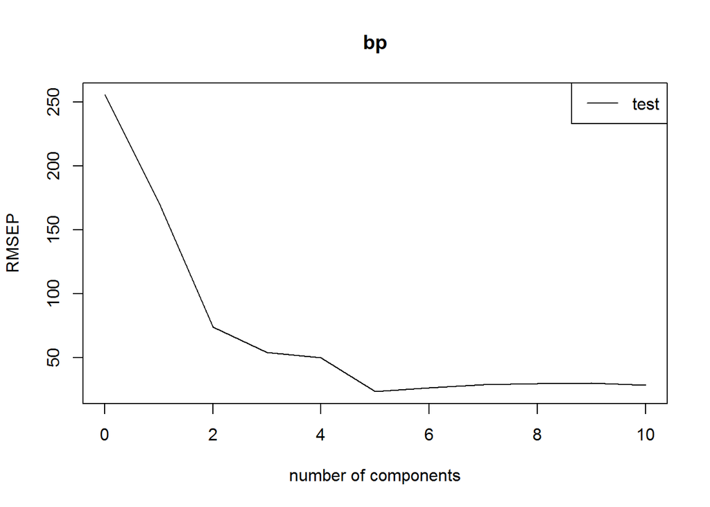

```r
# plot the RMSEP for the test set
plot(RMSEP(pls_model, newdata = test_set), legendpos = "topright")
```

```r
RMSEP(pls_model, newdata = test_set)
```

```
## (Intercept)      1 comps      2 comps      3 comps      4 comps
##      255.53       172.00        74.02        54.36        50.24
##     5 comps      6 comps      7 comps      8 comps      9 comps
##       23.67        26.52        29.26        30.09        30.45
##    10 comps
##       28.66
```

**R2 values**

```r
R2(pls_model, newdata = test_set)
```

```
## (Intercept)      1 comps      2 comps      3 comps      4 comps
##    -0.04737      0.52544      0.91211      0.95260      0.95951
##     5 comps      6 comps      7 comps      8 comps      9 comps
##     0.99101      0.98872      0.98626      0.98548      0.98512
##    10 comps
##     0.98682
```

## Second Model: Random Forest

### Feature selection

```r
# define seed for generating random numbers for reproducibility
set.seed(123)

# control variable with 10-fold cross validation
rfe_control <- rfeControl(functions=rfFuncs, method="cv", number=10)

# run the RFE algorithm
# 1st paramerer: the dataset without the dependent variable
# 2nd parameter: the vector holding the dependent variable(bp)
# 3rd parameter: the set of features sizes to be tested (10 features, 15 features ...etc)
feature_selection_model <- rfe(featuresDataframe[,1:ncol(featuresDataframe)-1], featuresDataframe[,ncol(featuresDataframe)], sizes=c(10,15,20,25,30), rfeControl=rfe_control)

# selecting the top 15 most important variables for our final dataset
selected_vars <- feature_selection_model$optVariables[1:15]

# select only the 15 columns from the features data frame
reducedFeaturesDataframe <- featuresDataframe[,which(unlist(colnames(featuresDataframe)) %in% selected_vars)]

# bind the boiling point column with the features data frame
reducedFeaturesDataframe <- cbind(reducedFeaturesDataframe, featuresDataframe[,ncol(featuresDataframe)])
colnames(reducedFeaturesDataframe)[ncol(reducedFeaturesDataframe)] <- "bp"

# summary of the 15 selected descriptors
summary(reducedFeaturesDataframe)
```

```
##      WPATH              WTPT.1           WTPT.2         MDEC.11
##  Min.   :     1.0   Min.   :  3.00   Min.   :1.500   Min.   :0.01010
##  1st Qu.:    71.5   1st Qu.: 14.50   1st Qu.:1.823   1st Qu.:0.01550
##  Median :  2300.0   Median : 46.83   Median :1.951   Median :0.04348
##  Mean   : 30222.3   Mean   : 73.94   Mean   :1.904   Mean   :0.58145
##  3rd Qu.: 46832.5   3rd Qu.:129.83   3rd Qu.:1.982   3rd Qu.:0.65076
##  Max.   :166650.0   Max.   :198.83   Max.   :1.988   Max.   :5.88040
##     MDEC.22         khs.ssCH2        Kier3            SP.3
##  Min.   : 0.000   Min.   : 0.0   Min.   : 0.00   Min.   : 0.000
##  1st Qu.: 0.000   1st Qu.: 4.0   1st Qu.: 7.20   1st Qu.: 1.868
##  Median : 0.000   Median :22.0   Median :23.05   Median : 5.457
##  Mean   : 3.876   Mean   :34.6   Mean   :36.08   Mean   : 8.923
##  3rd Qu.: 2.661   3rd Qu.:63.5   3rd Qu.:64.51   3rd Qu.:15.832
##  Max.   :35.803   Max.   :98.0   Max.   :99.01   Max.   :24.457
##       VP.3            C2SP3         BCUTc.1l          BCUTc.1h
##  Min.   : 0.000   Min.   : 0.0   Min.   :-0.1778   Min.   :0.04224
##  1st Qu.: 1.868   1st Qu.: 4.0   1st Qu.:-0.1705   1st Qu.:0.05025
##  Median : 5.457   Median :22.0   Median :-0.1705   Median :0.05229
##  Mean   : 8.923   Mean   :34.6   Mean   :-0.1688   Mean   :0.05359
##  3rd Qu.:15.832   3rd Qu.:63.5   3rd Qu.:-0.1698   3rd Qu.:0.05601
##  Max.   :24.457   Max.   :98.0   Max.   :-0.1570   Max.   :0.06472
##     BCUTp.1l         ATSp5            ALogP                bp
##  Min.   :3.760   Min.   :   0.0   Min.   :-28.1214   Min.   :184.6
##  1st Qu.:5.117   1st Qu.: 166.8   1st Qu.:-18.1854   1st Qu.:388.2
##  Median :5.117   Median :1096.9   Median : -6.2334   Median :653.1
##  Mean   :5.205   Mean   :1890.8   Mean   : -9.4209   Mean   :654.9
##  3rd Qu.:5.127   3rd Qu.:3511.0   3rd Qu.: -0.2733   3rd Qu.:909.7
##  Max.   :6.694   Max.   :5525.8   Max.   :  3.1124   Max.   :994.1
```

### Split the data

Randomly sample 20% of the total number of alkanes then create two datasets (train set and test set):

```r
# select ~20% test set
test_selection_rf <- sample(nrow(reducedFeaturesDataframe), 0.2 * nrow(reducedFeaturesDataframe))

traint_set_rf <- reducedFeaturesDataframe[-test_selection_rf,]
test_set_rf <- reducedFeaturesDataframe[test_selection_rf,]
```

### Build the model

Build the Random Forest model with 10-fold cross validation

```r
train.control <- trainControl(method = "cv", number = 10)

# Apply training using cross validation (train.control object) and random forest
rf_model <- train(bp ~ ., data=traint_set_rf, method = "rf",
                                 trControl = train.control)

print(rf_model)
```

```
## Random Forest
##
## 112 samples
##  15 predictor
##
## No pre-processing
## Resampling: Cross-Validated (10 fold)
## Summary of sample sizes: 102, 100, 101, 103, 100, 101, ...
## Resampling results across tuning parameters:
##
##   mtry  RMSE      Rsquared   MAE
##    2    27.45517  0.9844425  13.99111
##    8    26.00032  0.9854199  13.25270
##   15    26.45281  0.9850830  13.64828
##
## RMSE was used to select the optimal model using the smallest value.
## The final value used for the model was mtry = 8.
```

### Apply the prediction

```r
predict_rf <- predict(rf_model, newdata = test_set_rf)
```

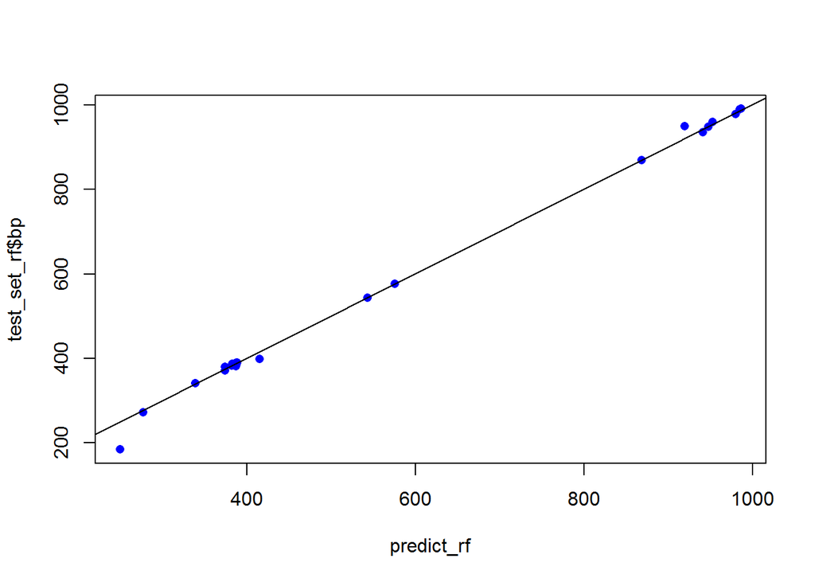

```r
plot (predict_rf, test_set_rf$bp, pch=16,col="blue")
abline(a=0,b=1,lwd=1)
```

```r
R2 <- 1 - (sum((test_set_rf$bp-predict_rf)^2)/sum((test_set_rf$bp-mean(test_set_rf$bp))^2))

R2
```

```
## [1] 0.996963
```

### By comparing the results of PLS and Random forest, we see that random forest gives better results